# Analysis of Longitudinal Data Part 1

Today is

```
## [1] "Mon Nov 30 21:57:41 2020"
```

This week we practise the analysis of longitudinal data. We will make graphical displays and summaries. We use the data RATS given by here: The data is from a nutrition study conducted in three groups of rats (Crowder and Hand, 1990). The three groups were put on different diets, and each animal’s body weight (grams) was recorded repeatedly (approximately weekly, except in week seven when two recordings were taken) over a 9-week period.

```r
# Access the packages dplyr and tidyr
library(dplyr)
```

```r
library(tidyr)
library(ggplot2)
library(knitr)

# Read the data
RATSL <- read.csv("/Users/teemupekkarinen/IODS-project/data/RATSL",row.names = 1,stringsAsFactors = T)
str(RATSL)
```

```
## 'data.frame':    176 obs. of  5 variables:
##  $ ID   : int  1 2 3 4 5 6 7 8 9 10 ...
##  $ Group: int  1 1 1 1 1 1 1 1 2 2 ...
##  $ Times: Factor w/ 11 levels "WD1","WD15","WD22",..: 1 1 1 1 1 1 1 1 1 1 ...
##  $ Rats : int  240 225 245 260 255 260 275 245 410 405 ...
##  $ Time : int  1 1 1 1 1 1 1 1 1 1 ...
```

```r
dim(RATSL)
```

```
## [1] 176   5
```

```r
summary(RATSL)
```

```
##        ID            Group          Times         Rats            Time
##  Min.   : 1.00   Min.   :1.00   WD1    :16   Min.   :225.0   Min.   : 1.00
##  1st Qu.: 4.75   1st Qu.:1.00   WD15   :16   1st Qu.:267.0   1st Qu.:15.00
##  Median : 8.50   Median :1.50   WD22   :16   Median :344.5   Median :36.00
##  Mean   : 8.50   Mean   :1.75   WD29   :16   Mean   :384.5   Mean   :33.55
##  3rd Qu.:12.25   3rd Qu.:2.25   WD36   :16   3rd Qu.:511.2   3rd Qu.:50.00
##  Max.   :16.00   Max.   :3.00   WD43   :16   Max.   :628.0   Max.   :64.00
##                                 (Other):80
```

```r
# Factor ID & Group
RATSL$ID <- factor(RATSL$ID)
RATSL$Group <- factor(RATSL$Group)

# Take a glimpse at the RATSL data
glimpse(RATSL)
```

```
## Rows: 176
## Columns: 5
## $ ID    <fct> 1, 2, 3, 4, 5, 6, 7, 8, 9, 10, 11, 12, 13, 14, 15, 16, 1, 2, 3,…
## $ Group <fct> 1, 1, 1, 1, 1, 1, 1, 1, 2, 2, 2, 2, 3, 3, 3, 3, 1, 1, 1, 1, 1, …
## $ Times <fct> WD1, WD1, WD1, WD1, WD1, WD1, WD1, WD1, WD1, WD1, WD1, WD1, WD1…
## $ Rats  <int> 240, 225, 245, 260, 255, 260, 275, 245, 410, 405, 445, 555, 470…
## $ Time  <int> 1, 1, 1, 1, 1, 1, 1, 1, 1, 1, 1, 1, 1, 1, 1, 1, 8, 8, 8, 8, 8, …
```

```r
# Table
kable(RATSL[1:16,])
```

| ID | Group | Times | Rats | Time |
| --- | --- | --- | --- | --- |
| 1 | 1 | WD1 | 240 | 1 |
| 2 | 1 | WD1 | 225 | 1 |
| 3 | 1 | WD1 | 245 | 1 |
| 4 | 1 | WD1 | 260 | 1 |
| 5 | 1 | WD1 | 255 | 1 |
| 6 | 1 | WD1 | 260 | 1 |
| 7 | 1 | WD1 | 275 | 1 |
| 8 | 1 | WD1 | 245 | 1 |
| 9 | 2 | WD1 | 410 | 1 |
| 10 | 2 | WD1 | 405 | 1 |
| 11 | 2 | WD1 | 445 | 1 |
| 12 | 2 | WD1 | 555 | 1 |
| 13 | 3 | WD1 | 470 | 1 |
| 14 | 3 | WD1 | 535 | 1 |
| 15 | 3 | WD1 | 520 | 1 |
| 16 | 3 | WD1 | 510 | 1 |

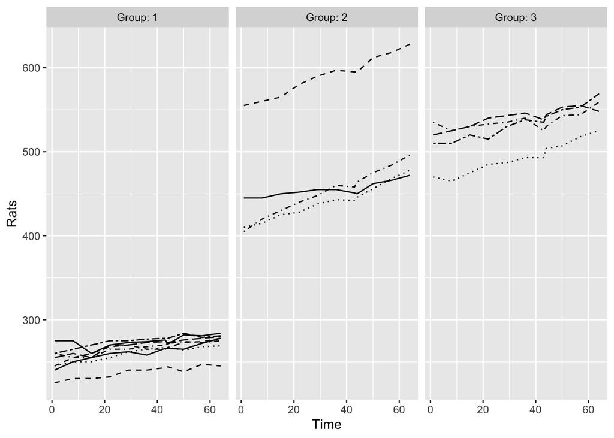

```r
# Draw the plot
ggplot(RATSL, aes(x = Time, y = Rats, linetype = ID)) +
  geom_line() +
  scale_linetype_manual(values = rep(1:10, times=4)) +
  facet_grid(. ~ Group, labeller = label_both) +
  theme(legend.position = "none") +
  scale_y_continuous(limits = c(min(RATSL$Rats), max(RATSL$Rats)))
```

That is, there are different 16 rats for which the table above gives the initial weight in day 1. The first figure shows how the weight of rats in each group evolve over the test period. Clearly there are differences in weights between groups. Moreover, in group 2 there is a clear outlier of a huge rat. It seems to be so that, in group there are the lightest rats, in group 2 the second lightest (exept the outlier rat), and in group the heaviest. In all groups the weight of rats increased during the test period. How much, is the question we try to answer next.

Once we standardise the weights of rats by grouping on each time period, we observe that the weight of rats in group 1 are all the time below the average (at each time) and rats in groups 2 and 3 above the average.

```r
# Standardise the variable Rats
RATSL <- RATSL %>%
  group_by(Time) %>%
  mutate(stdRats = (Rats - mean(Rats))/sd(Rats) ) %>%
  ungroup()

# Glimpse the data
glimpse(RATSL)
```

```
## Rows: 176
## Columns: 6
## $ ID      <fct> 1, 2, 3, 4, 5, 6, 7, 8, 9, 10, 11, 12, 13, 14, 15, 16, 1, 2, …
## $ Group   <fct> 1, 1, 1, 1, 1, 1, 1, 1, 2, 2, 2, 2, 3, 3, 3, 3, 1, 1, 1, 1, 1…
## $ Times   <fct> WD1, WD1, WD1, WD1, WD1, WD1, WD1, WD1, WD1, WD1, WD1, WD1, W…
## $ Rats    <int> 240, 225, 245, 260, 255, 260, 275, 245, 410, 405, 445, 555, 4…
## $ Time    <int> 1, 1, 1, 1, 1, 1, 1, 1, 1, 1, 1, 1, 1, 1, 1, 1, 8, 8, 8, 8, 8…
## $ stdRats <dbl> -1.0011429, -1.1203857, -0.9613953, -0.8421525, -0.8819001, -…
```

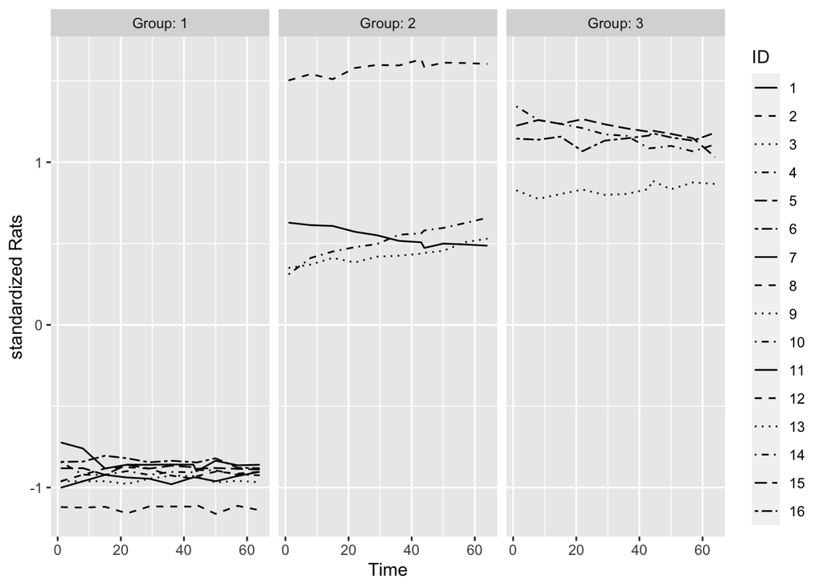

```r
# Plot again with the standardised Rats
ggplot(RATSL, aes(x = Time, y = stdRats, linetype = ID)) +
  geom_line() +
  scale_linetype_manual(values = rep(1:10, times=4)) +
  facet_grid(. ~ Group, labeller = label_both) +
  scale_y_continuous(name = "standardized Rats")
```

Next we look at how the mean of rats in each group evolve over time. We observe that basically the means of weight of rats increase in every group

```r
# Number of time periods, baseline (time 1) included
n <- RATSL$Time %>% unique() %>% length()

# Summary data with mean and standard error of Rats by Group and Time
RATSS <- RATSL %>%
  group_by(Group, Time) %>%
  summarise( mean = mean(Rats), se = sd(Rats)/sqrt(n) ) %>%
  ungroup()
# Glimpse the data
glimpse(RATSS)
```

```
## Rows: 33
## Columns: 4
## $ Group <fct> 1, 1, 1, 1, 1, 1, 1, 1, 1, 1, 1, 2, 2, 2, 2, 2, 2, 2, 2, 2, 2, …
## $ Time  <int> 1, 8, 15, 22, 29, 36, 43, 44, 50, 57, 64, 1, 8, 15, 22, 29, 36,…
## $ mean  <dbl> 250.625, 255.000, 254.375, 261.875, 264.625, 265.000, 267.375, …
## $ se    <dbl> 4.589478, 3.947710, 3.460116, 4.100800, 3.333956, 3.552939, 3.3…
```

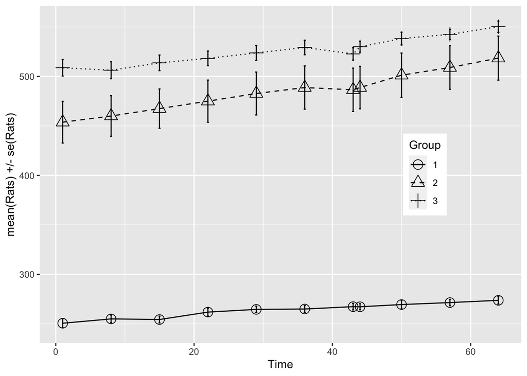

```r
# Plot the mean profiles
ggplot(RATSS, aes(x = Time, y = mean, linetype=Group, shape = Group)) +
  geom_line() +
  scale_linetype_manual(values = c(1,2,3)) +
  geom_point(size=4) +
  scale_shape_manual(values = c(1,2,3)) +
  geom_errorbar(aes(ymin = mean - se, ymax = mean + se, linetype="1"), width=0.3) +
  theme(legend.position = c(0.8,0.5)) +
  scale_y_continuous(name = "mean(Rats) +/- se(Rats)")
```

Next, we create a summary data by Group and ID with mean as the summary variable (ignoring baseline time period 1). The box plots of the full data and without the outlier rat are given below.

```r
# Create a summary data by Group and ID with mean as the summary variable (ignoring baseline time period 1).
RATSL8S <- RATSL %>%
  filter(Time > 1) %>%
  group_by(Group, ID) %>%
  summarise( mean=mean(Rats) ) %>%
  ungroup()
# Glimpse the data
glimpse(RATSL8S)
```

```
## Rows: 16
## Columns: 3
## $ Group <fct> 1, 1, 1, 1, 1, 1, 1, 1, 2, 2, 2, 2, 3, 3, 3, 3
## $ ID    <fct> 1, 2, 3, 4, 5, 6, 7, 8, 9, 10, 11, 12, 13, 14, 15, 16
## $ mean  <dbl> 263.2, 238.9, 261.7, 267.2, 270.9, 276.2, 274.6, 267.5, 443.9, …
```

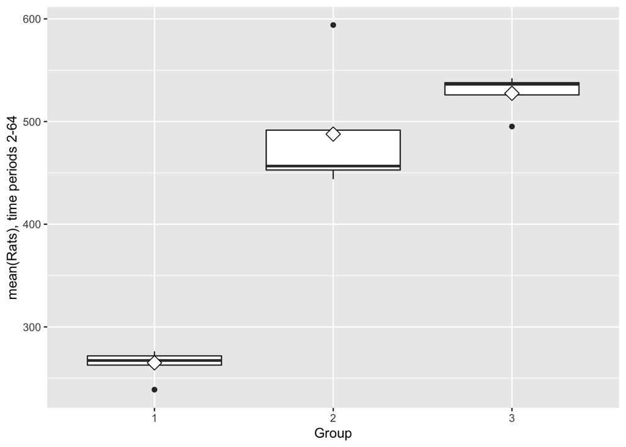

```r
# Draw a boxplot of the mean versus treatment
ggplot(RATSL8S, aes(x = Group, y = mean)) +
  geom_boxplot() +
  stat_summary(fun = "mean", geom = "point", shape=23, size=4, fill = "white") +
  scale_y_continuous(name = "mean(Rats), time periods 2-64")
```

```r
# Create a new data by filtering the outlier and adjust the ggplot code the draw the plot again with the new data
RATSL8S1 <- RATSL8S %>%
  filter(mean < 550)

# Glimpse the data
glimpse(RATSL8S1)
```

```
## Rows: 15
## Columns: 3
## $ Group <fct> 1, 1, 1, 1, 1, 1, 1, 1, 2, 2, 2, 3, 3, 3, 3
## $ ID    <fct> 1, 2, 3, 4, 5, 6, 7, 8, 9, 10, 11, 13, 14, 15, 16
## $ mean  <dbl> 263.2, 238.9, 261.7, 267.2, 270.9, 276.2, 274.6, 267.5, 443.9, …
```

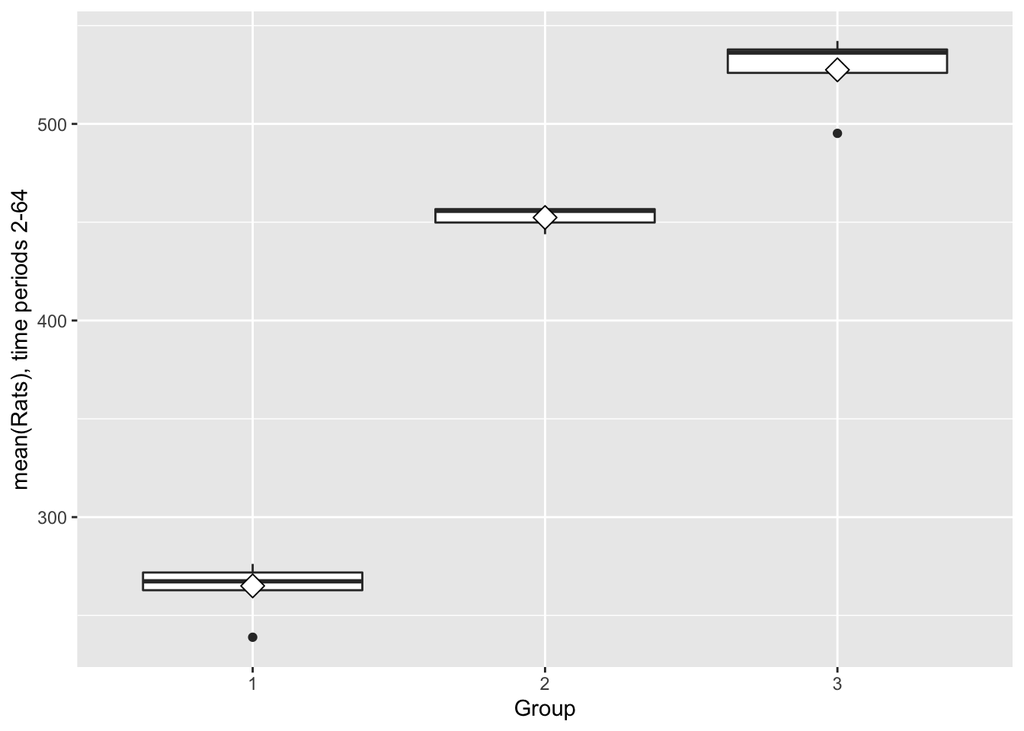

```r
# Draw a boxplot of the mean versus treatment
ggplot(RATSL8S1, aes(x = Group, y = mean)) +
  geom_boxplot() +
  stat_summary(fun = "mean", geom = "point", shape=23, size=4, fill = "white") +
  scale_y_continuous(name = "mean(Rats), time periods 2-64")
```

```r
# Perform a two-sample t-test

# Let us put groups 2 and 3 together in order to run the t-test
RATSL8S1$Group[which(RATSL8S1$Group==2)] <- 3
t.test(mean~Group, data = RATSL8S1, var.equal = TRUE)
```

```
##
##  Two Sample t-test
##
## data:  mean by Group
## t = -14.554, df = 13, p-value = 2.002e-09
## alternative hypothesis: true difference in means is not equal to 0
## 95 percent confidence interval:
##  -264.4733 -196.1053
## sample estimates:
## mean in group 1 mean in group 3
##        265.0250        495.3143
```

```r
# Add the baseline from the original data as a new variable to the summary data
RATSL8S2 <- RATSL8S %>%
  mutate(baseline = RATSL$Rats[which(RATSL$Times=="WD1")])

# Fit the linear model with the mean as the response
fit <- lm(mean ~ baseline + Group, data = RATSL8S2)
summary(fit)
```

```
##
## Call:
## lm(formula = mean ~ baseline + Group, data = RATSL8S2)
##
## Residuals:
##     Min      1Q  Median      3Q     Max
## -23.905  -4.194   2.190   7.577  14.800
##
## Coefficients:
##             Estimate Std. Error t value Pr(>|t|)
## (Intercept) 33.16375   21.87657   1.516   0.1554
## baseline     0.92513    0.08572  10.793 1.56e-07 ***
## Group2      34.85753   18.82308   1.852   0.0888 .
## Group3      23.67526   23.25324   1.018   0.3287
## ---
## Signif. codes:  0 '***' 0.001 '**' 0.01 '*' 0.05 '.' 0.1 ' ' 1
##
## Residual standard error: 11.68 on 12 degrees of freedom
## Multiple R-squared:  0.9936, Adjusted R-squared:  0.992
## F-statistic: 622.1 on 3 and 12 DF,  p-value: 1.989e-13
```

```r
# Compute the analysis of variance table for the fitted model with anova()
anova(fit)
```

```
## Analysis of Variance Table
##
## Response: mean
##           Df Sum Sq Mean Sq   F value   Pr(>F)
## baseline   1 253625  253625 1859.8201 1.57e-14 ***
## Group      2    879     439    3.2219  0.07586 .
## Residuals 12   1636     136
## ---
## Signif. codes:  0 '***' 0.001 '**' 0.01 '*' 0.05 '.' 0.1 ' ' 1
```

```r
kable(anova(fit))
```

|  | Df | Sum Sq | Mean Sq | F value | Pr(>F) |
| --- | --- | --- | --- | --- | --- |
| baseline | 1 | 253625.4006 | 253625.4006 | 1859.820128 | 0.0000000 |
| Group | 2 | 878.7458 | 439.3729 | 3.221896 | 0.0758554 |
| Residuals | 12 | 1636.4512 | 136.3709 | NA | NA |

# Analysis of Longitudinal Data Part 2

In this part we go a little deeper to the analysis comparing to the Part 1. As in the course book it says:

“The summary measure approach to the analysis of longitudinal data described in the previous chapter sometimes provides a useful first step in making inferences about the data, but it is really only ever a first step, and a more complete and a more appropriate analysis will involve fitting a suitable model to the data and estimating parameters that link the explanatory variables of interest to the repeated measures of the response variable”

To that end, we use Linear Mixed Effects Models for repeated measures data. To begin to see how linear mixed effects models are applied in practice, we shall use some data from Davis (2002): “Here 40 male subjects were randomly assigned to one of two treatment groups and each subject was rated on the brief psychiatric rating scale (BPRS) measured before treatment began (week 0) and then at weekly intervals for eight weeks. The BPRS assesses the level of 18 symptom constructs such as hostility, suspiciousness, hallucinations and grandiosity; each of these is rated from one (not present) to seven (extremely severe). The scale is used to evaluate patients suspected of having schizophrenia.”

We now describre the data in the similar way as for RATS data. The summaries and structure and a plot for the treatment group and control group is given. We observe the following

- the BPRS score of almost all the men is decreasing over the eight weeks of the study. -the men who have higher BPRS values at the beginning tend to have higher values throughout the study.
- there are substantial individual differences and variability appears to decrease with time.

```r
# Access the packages dplyr and tidyr
library(dplyr)
library(tidyr)
library(ggplot2)
library(knitr)

# Read the data
BPRSL <- read.csv("/Users/teemupekkarinen/IODS-project/data/BPRSL",row.names = 1,stringsAsFactors = T)
str(BPRSL)
```

```
## 'data.frame':    360 obs. of  5 variables:
##  $ treatment: int  1 1 1 1 1 1 1 1 1 1 ...
##  $ subject  : int  1 2 3 4 5 6 7 8 9 10 ...
##  $ weeks    : Factor w/ 9 levels "week0","week1",..: 1 1 1 1 1 1 1 1 1 1 ...
##  $ bprs     : int  42 58 54 55 72 48 71 30 41 57 ...
##  $ week     : int  0 0 0 0 0 0 0 0 0 0 ...
```

```r
dim(BPRSL)
```

```
## [1] 360   5
```

```r
summary(BPRSL)
```

```
##    treatment      subject          weeks          bprs            week
##  Min.   :1.0   Min.   : 1.00   week0  : 40   Min.   :18.00   Min.   :0
##  1st Qu.:1.0   1st Qu.: 5.75   week1  : 40   1st Qu.:27.00   1st Qu.:2
##  Median :1.5   Median :10.50   week2  : 40   Median :35.00   Median :4
##  Mean   :1.5   Mean   :10.50   week3  : 40   Mean   :37.66   Mean   :4
##  3rd Qu.:2.0   3rd Qu.:15.25   week4  : 40   3rd Qu.:43.00   3rd Qu.:6
##  Max.   :2.0   Max.   :20.00   week5  : 40   Max.   :95.00   Max.   :8
##                                (Other):120
```

```r
# Factor subject & treatment
BPRSL$subject <- factor(BPRSL$subject)
BPRSL$treatment <- factor(BPRSL$treatment)

# Take a glimpse at the RATSL data
glimpse(BPRSL)
```

```
## Rows: 360
## Columns: 5
## $ treatment <fct> 1, 1, 1, 1, 1, 1, 1, 1, 1, 1, 1, 1, 1, 1, 1, 1, 1, 1, 1, 1,…
## $ subject   <fct> 1, 2, 3, 4, 5, 6, 7, 8, 9, 10, 11, 12, 13, 14, 15, 16, 17, …
## $ weeks     <fct> week0, week0, week0, week0, week0, week0, week0, week0, wee…
## $ bprs      <int> 42, 58, 54, 55, 72, 48, 71, 30, 41, 57, 30, 55, 36, 38, 66,…
## $ week      <int> 0, 0, 0, 0, 0, 0, 0, 0, 0, 0, 0, 0, 0, 0, 0, 0, 0, 0, 0, 0,…
```

```r
# Table
kable(BPRSL[1:20,])
```

| treatment | subject | weeks | bprs | week |
| --- | --- | --- | --- | --- |
| 1 | 1 | week0 | 42 | 0 |
| 1 | 2 | week0 | 58 | 0 |
| 1 | 3 | week0 | 54 | 0 |
| 1 | 4 | week0 | 55 | 0 |
| 1 | 5 | week0 | 72 | 0 |
| 1 | 6 | week0 | 48 | 0 |
| 1 | 7 | week0 | 71 | 0 |
| 1 | 8 | week0 | 30 | 0 |
| 1 | 9 | week0 | 41 | 0 |
| 1 | 10 | week0 | 57 | 0 |
| 1 | 11 | week0 | 30 | 0 |
| 1 | 12 | week0 | 55 | 0 |
| 1 | 13 | week0 | 36 | 0 |
| 1 | 14 | week0 | 38 | 0 |
| 1 | 15 | week0 | 66 | 0 |
| 1 | 16 | week0 | 41 | 0 |
| 1 | 17 | week0 | 45 | 0 |
| 1 | 18 | week0 | 39 | 0 |
| 1 | 19 | week0 | 24 | 0 |
| 1 | 20 | week0 | 38 | 0 |

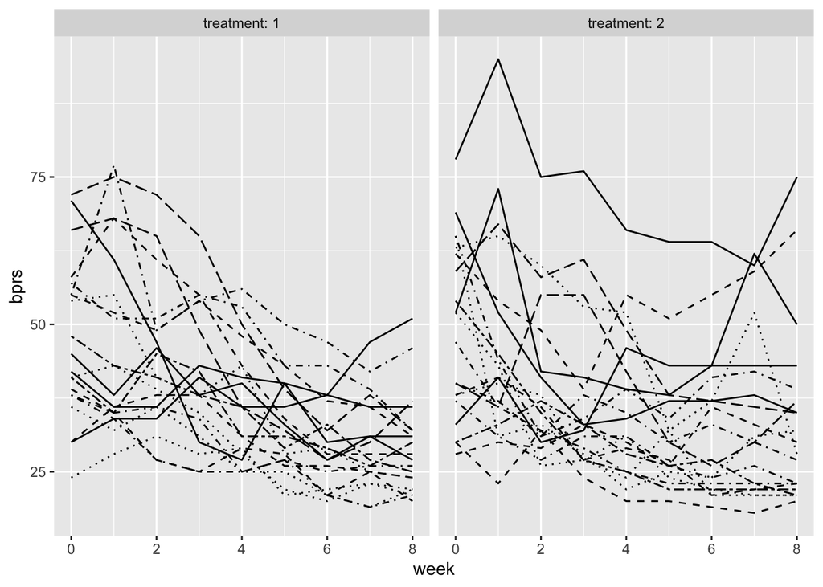

```r
# Draw the plot
ggplot(BPRSL, aes(x = week, y = bprs, linetype = subject)) +
  geom_line() +
  scale_linetype_manual(values = rep(1:10, times=4)) +
  facet_grid(. ~ treatment, labeller = label_both) +
  theme(legend.position = "none") +
  scale_y_continuous(limits = c(min(BPRSL$bprs), max(BPRSL$bprs)))
```

Let us next jump into the regression model.

```r
# create a regression model BPRSL_reg
BPRSL_reg <- lm(bprs ~ week + treatment, data = BPRSL)

# print out a summary of the model
summary(BPRSL_reg)
```

```
##
## Call:
## lm(formula = bprs ~ week + treatment, data = BPRSL)
##
## Residuals:
##     Min      1Q  Median      3Q     Max
## -22.454  -8.965  -3.196   7.002  50.244
##
## Coefficients:
##             Estimate Std. Error t value Pr(>|t|)
## (Intercept)  46.4539     1.3670  33.982   <2e-16 ***
## week         -2.2704     0.2524  -8.995   <2e-16 ***
## treatment2    0.5722     1.3034   0.439    0.661
## ---
## Signif. codes:  0 '***' 0.001 '**' 0.01 '*' 0.05 '.' 0.1 ' ' 1
##
## Residual standard error: 12.37 on 357 degrees of freedom
## Multiple R-squared:  0.1851, Adjusted R-squared:  0.1806
## F-statistic: 40.55 on 2 and 357 DF,  p-value: < 2.2e-16
```

From here we observe that there is a little, unsignificant positive effect of treatment. Moreover, there is a significant negative effect of time.

This model assumes independence of the repeated measures of brps, which is unrealistic. Next we consider the random intercept model. Fitting a random intercept model allows the linear regression fit for each subject to differ in intercept from other subjects.

```r
# dplyr, tidyr, RATS and RATSL are available

# access library lme4
library(lme4)
# Create a random intercept model
BPRSL_ref <- lmer(bprs ~ week + treatment + (1 | subject), data = BPRSL, REML = FALSE)

# Print the summary of the model
summary(BPRSL_ref)
```

```
## Linear mixed model fit by maximum likelihood  ['lmerMod']
## Formula: bprs ~ week + treatment + (1 | subject)
##    Data: BPRSL
##
##      AIC      BIC   logLik deviance df.resid
##   2748.7   2768.1  -1369.4   2738.7      355
##
## Scaled residuals:
##     Min      1Q  Median      3Q     Max
## -3.0481 -0.6749 -0.1361  0.4813  3.4855
##
## Random effects:
##  Groups   Name        Variance Std.Dev.
##  subject  (Intercept)  47.41    6.885
##  Residual             104.21   10.208
## Number of obs: 360, groups:  subject, 20
##
## Fixed effects:
##             Estimate Std. Error t value
## (Intercept)  46.4539     1.9090  24.334
## week         -2.2704     0.2084 -10.896
## treatment2    0.5722     1.0761   0.532
##
## Correlation of Fixed Effects:
##            (Intr) week
## week       -0.437
## treatment2 -0.282  0.000
```

The week fixed effects remain negative and significant as well as the treatment effect is positive but unsignificant. Correlation of fixed effects shows negative effects on both week and treatment.

```r
# create a random intercept and random slope model
BPRSL_ref1 <- lmer(bprs ~ week + treatment + (week | subject), data = BPRSL, REML = FALSE)

# print a summary of the model
summary(BPRSL_ref1)
```

```
## Linear mixed model fit by maximum likelihood  ['lmerMod']
## Formula: bprs ~ week + treatment + (week | subject)
##    Data: BPRSL
##
##      AIC      BIC   logLik deviance df.resid
##   2745.4   2772.6  -1365.7   2731.4      353
##
## Scaled residuals:
##     Min      1Q  Median      3Q     Max
## -2.8919 -0.6194 -0.0691  0.5531  3.7976
##
## Random effects:
##  Groups   Name        Variance Std.Dev. Corr
##  subject  (Intercept) 64.8222  8.0512
##           week         0.9609  0.9802   -0.51
##  Residual             97.4305  9.8707
## Number of obs: 360, groups:  subject, 20
##
## Fixed effects:
##             Estimate Std. Error t value
## (Intercept)  46.4539     2.1052  22.066
## week         -2.2704     0.2977  -7.626
## treatment2    0.5722     1.0405   0.550
##
## Correlation of Fixed Effects:
##            (Intr) week
## week       -0.582
## treatment2 -0.247  0.000
```

```r
# perform an ANOVA test on the two models
anova(BPRSL_ref1, BPRSL_ref)
```

```
## Data: BPRSL
## Models:
## BPRSL_ref: bprs ~ week + treatment + (1 | subject)
## BPRSL_ref1: bprs ~ week + treatment + (week | subject)
##            npar    AIC    BIC  logLik deviance  Chisq Df Pr(>Chisq)
## BPRSL_ref     5 2748.7 2768.1 -1369.4   2738.7
## BPRSL_ref1    7 2745.4 2772.6 -1365.7   2731.4 7.2721  2    0.02636 *
## ---
## Signif. codes:  0 '***' 0.001 '**' 0.01 '*' 0.05 '.' 0.1 ' ' 1
```

From here we observe that there are no very much different to the earlier results; actually all signs and significancies remain the same.

Finally, we can fit a random intercept and slope model that allows for a treatment $\times$ week interaction.

```r
# create a random intercept and random slope model
BPRSL_ref2 <- lmer(bprs ~ week * treatment + (week | subject), data = BPRSL, REML = FALSE)

# print a summary of the model
summary(BPRSL_ref2)
```

```
## Linear mixed model fit by maximum likelihood  ['lmerMod']
## Formula: bprs ~ week * treatment + (week | subject)
##    Data: BPRSL
##
##      AIC      BIC   logLik deviance df.resid
##   2744.3   2775.4  -1364.1   2728.3      352
##
## Scaled residuals:
##     Min      1Q  Median      3Q     Max
## -3.0512 -0.6271 -0.0768  0.5288  3.9260
##
## Random effects:
##  Groups   Name        Variance Std.Dev. Corr
##  subject  (Intercept) 64.9964  8.0620
##           week         0.9687  0.9842   -0.51
##  Residual             96.4707  9.8220
## Number of obs: 360, groups:  subject, 20
##
## Fixed effects:
##                 Estimate Std. Error t value
## (Intercept)      47.8856     2.2521  21.262
## week             -2.6283     0.3589  -7.323
## treatment2       -2.2911     1.9090  -1.200
## week:treatment2   0.7158     0.4010   1.785
##
## Correlation of Fixed Effects:
##             (Intr) week   trtmn2
## week        -0.650
## treatment2  -0.424  0.469
## wek:trtmnt2  0.356 -0.559 -0.840
```

```r
# perform an ANOVA test on the two models
anova(BPRSL_ref2, BPRSL_ref1)
```

```
## Data: BPRSL
## Models:
## BPRSL_ref1: bprs ~ week + treatment + (week | subject)
## BPRSL_ref2: bprs ~ week * treatment + (week | subject)
##            npar    AIC    BIC  logLik deviance  Chisq Df Pr(>Chisq)
## BPRSL_ref1    7 2745.4 2772.6 -1365.7   2731.4
## BPRSL_ref2    8 2744.3 2775.4 -1364.1   2728.3 3.1712  1    0.07495 .
## ---
## Signif. codes:  0 '***' 0.001 '**' 0.01 '*' 0.05 '.' 0.1 ' ' 1
```

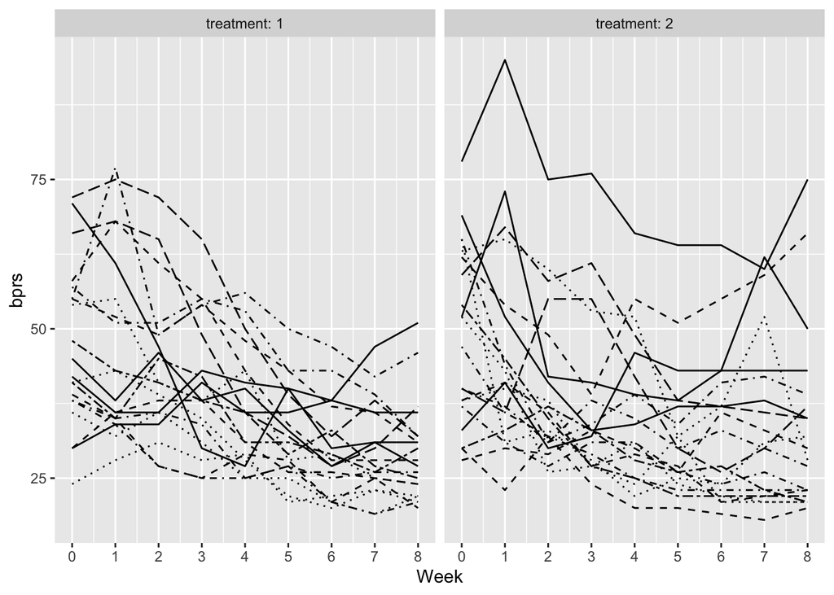

```r
# draw the plot of BPRSL
ggplot(BPRSL, aes(x = week, y = bprs, linetype = subject)) +
  geom_line() +
  scale_linetype_manual(values = rep(1:10, times=4)) +
  facet_grid(. ~ treatment, labeller = label_both) +
  theme(legend.position = "none") +
  scale_y_continuous(limits = c(min(BPRSL$bprs), max(BPRSL$bprs))) +
  scale_x_continuous(name = "Week", breaks = seq(0, 8, 1))
```

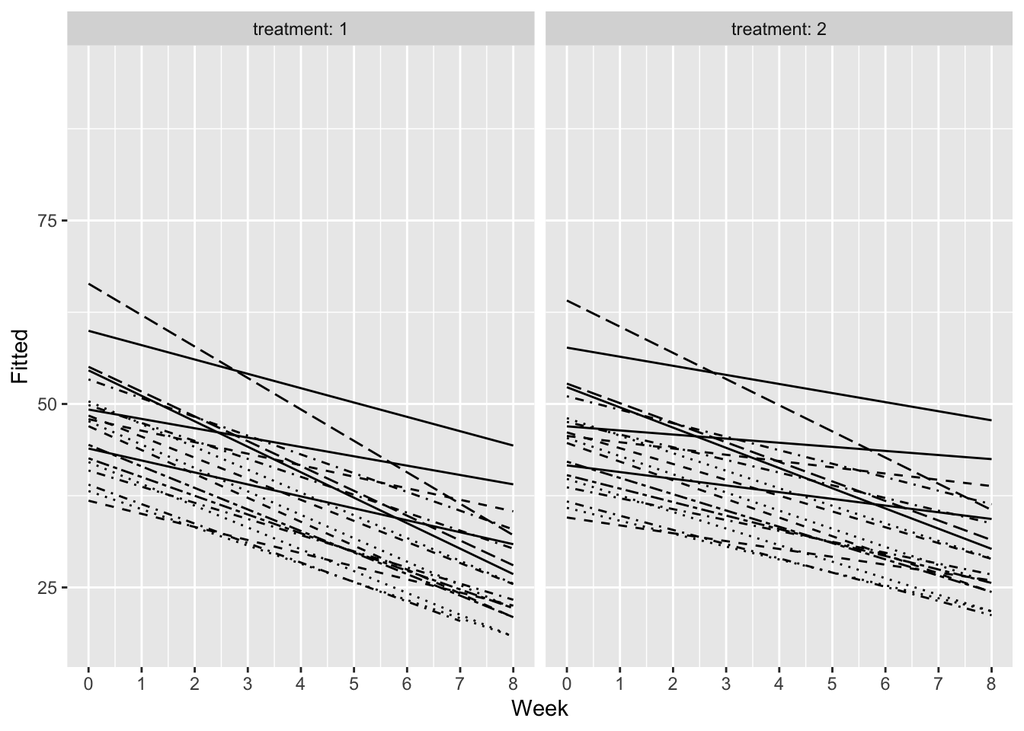

```r
# Create a vector of the fitted values
Fitted <- fitted(BPRSL_ref2)

# Create a new column fitted to BPRSL
BPRSL <- BPRSL %>%
  mutate(Fitted)

# draw the plot of BPRSL
ggplot(BPRSL, aes(x = week, y = Fitted, linetype = subject)) +
  geom_line() +
  scale_linetype_manual(values = rep(1:10, times=4)) +
  facet_grid(. ~ treatment, labeller = label_both) +
  theme(legend.position = "none") +
  scale_y_continuous(limits = c(min(BPRSL$bprs), max(BPRSL$bprs))) +
  scale_x_continuous(name = "Week", breaks = seq(0, 8, 1))
```

By adding the interaction term the sign of treament changes to negative. the coefficient of the interaction term is positive, but pretty unsignificant. The similar effects happen in the correlation of fixed effects.

We fit the model and observe that the the fit is pretty good.